# solution-v2

### Challenge

```python
!python --version
```

```
Python 3.11.4
```

```python
import econml
import numpy as np
import pandas as pd

import matplotlib.pyplot as plt
import seaborn as sns

import statsmodels.api as sm
from sklearn.model_selection import StratifiedKFold
from sklearn.metrics import accuracy_score, classification_report, confusion_matrix, log_loss

import lightgbm as lgb
from lightgbm import LGBMClassifier, LGBMRegressor

from IPython import display

import shap
shap.initjs()

import warnings
warnings.filterwarnings('ignore')

sns.set_style('darkgrid')
```

### Problem 1: **Content optimisation**

We currently have a very large library of voices and sounds. Sounds are grouped in “Theme packs” (Like Xmas, Video Games, movie titles etc). Each week each user gets one pack for free. You are told to maximize the usage of the weekly packs. What would you do? What data would you need?

KPI definition: seconds used per user (per week?)

Objective: max sum(`seconds_used`) AND min(`churn_value`)

data:

- user features (geography, meta-features, etc)
  - `churn`
- temporal features
  - `woy`
  - `dow`
  - ...
- `theme_id`
- theme features
- `voice/effect_id`
- voice/effect features

Target

sum of seconds the user used a specific unit of aggregation of the product (over a week?)

for each combinations of each user + temporal features, simulate and optimize to determine the best:

- theme pack
- composition of the theme pack

by selecting the top 10 with greateast sum of seconds predicted!

problem #1: closed feedback loops

- introduce an exploration/exploitation mechanism:
  - based on a different level of aggregation?
  - pick randomly 10%?
    - can annoy users with stupid recommendations: instead of completely random, select top 11-20?

### Problem 2: **Churn reduction**

Among others, we have a subscription business model where optimizing churn is a key factor. Here you have a telco client churn sample data:

- a. Gather some insights from the data to identify the factors driving high customer churn.
- b. Develop a simple churn prediction model to accurately explain customer churn.
- c. Prescribe personalized actions to retain customers and reduce churn.

```python
df = pd.read_csv("./churn/telco_churn_data.csv")
```

```python
df.head()
```

|  | Customer ID | Referred a Friend | Number of Referrals | Tenure in Months | Offer | Phone Service | Avg Monthly Long Distance Charges | Multiple Lines | Internet Service | Internet Type | ... | Latitude | Longitude | Population | Churn Value | CLTV | Churn Category | Churn Reason | Total Customer Svc Requests | Product/Service Issues Reported | Customer Satisfaction |
| --- | --- | --- | --- | --- | --- | --- | --- | --- | --- | --- | --- | --- | --- | --- | --- | --- | --- | --- | --- | --- | --- |
| 0 | 8779-QRDMV | No | 0 | 1 | None | No | 0.00 | No | Yes | Fiber Optic | ... | 34.023810 | -118.156582 | 68701 | 1 | 5433 | Competitor | Competitor offered more data | 5 | 0 | NaN |
| 1 | 7495-OOKFY | Yes | 1 | 8 | Offer E | Yes | 48.85 | Yes | Yes | Cable | ... | 34.044271 | -118.185237 | 55668 | 1 | 5302 | Competitor | Competitor made better offer | 5 | 0 | NaN |
| 2 | 1658-BYGOY | No | 0 | 18 | Offer D | Yes | 11.33 | Yes | Yes | Fiber Optic | ... | 34.108833 | -118.229715 | 47534 | 1 | 3179 | Competitor | Competitor made better offer | 1 | 0 | NaN |
| 3 | 4598-XLKNJ | Yes | 1 | 25 | Offer C | Yes | 19.76 | No | Yes | Fiber Optic | ... | 33.936291 | -118.332639 | 27778 | 1 | 5337 | Dissatisfaction | Limited range of services | 1 | 1 | 2.0 |
| 4 | 4846-WHAFZ | Yes | 1 | 37 | Offer C | Yes | 6.33 | Yes | Yes | Cable | ... | 33.972119 | -118.020188 | 26265 | 1 | 2793 | Price | Extra data charges | 1 | 0 | 2.0 |

5 rows × 46 columns

### Exploratory Data Analysis

```python
df["Customer ID"].nunique()
```

```
7043
```

```python
df.shape
```

```
(7043, 46)
```

The dataset has 7043 rows and 46 features.

```python
df.info()
```

```
<class 'pandas.core.frame.DataFrame'>
RangeIndex: 7043 entries, 0 to 7042
Data columns (total 46 columns):
 #   Column                             Non-Null Count  Dtype
---  ------                             --------------  -----
 0   Customer ID                        7043 non-null   object
 1   Referred a Friend                  7043 non-null   object
 2   Number of Referrals                7043 non-null   int64
 3   Tenure in Months                   7043 non-null   int64
 4   Offer                              7043 non-null   object
 5   Phone Service                      7043 non-null   object
 6   Avg Monthly Long Distance Charges  7043 non-null   float64
 7   Multiple Lines                     7043 non-null   object
 8   Internet Service                   7043 non-null   object
 9   Internet Type                      7043 non-null   object
```

[output cut: 38 more lines]

Looks like there's no int columns that are indeed categorical. Most variables are encoded as categorical variables, a.k.a `object`

Moving on....

```python
cat_cols = []
target_cols = []
num_cols = []
for c in df.columns:
    col_type = df[c].dtype
    if c != "Churn Value":
        if col_type == "object" or col_type.name == "category":
            df[c] = df[c].astype('category')
            cat_cols.append(c)
        elif col_type == "float64" or col_type == "int64":
            df[c] = (df[c] - df[c].min()) / (df[c].max() - df[c].min())
            num_cols.append(c)
    else:
        target_cols.append(c)
```

```python
cat_cols
```

```
['Customer ID',
 'Referred a Friend',
 'Offer',
 'Phone Service',
 'Multiple Lines',
 'Internet Service',
 'Internet Type',
 'Online Security',
 'Online Backup',
 'Device Protection Plan',
 'Premium Tech Support',
 'Streaming TV',
 'Streaming Movies',
 'Streaming Music',
 'Unlimited Data',
 'Contract',
 'Paperless Billing',
 'Payment Method',
 'Gender',
 'Under 30',
 'Senior Citizen',
 'Married',
 'Dependents',
 'City',
 'Churn Category',
 'Churn Reason']
```

```python
num_cols
```

```
['Number of Referrals',
 'Tenure in Months',
 'Avg Monthly Long Distance Charges',
 'Avg Monthly GB Download',
 'Monthly Charge',
 'Total Regular Charges',
 'Total Refunds',
 'Total Extra Data Charges',
 'Total Long Distance Charges',
 'Age',
 'Number of Dependents',
 'Zip Code',
 'Latitude',
 'Longitude',
 'Population',
 'CLTV',
 'Total Customer Svc Requests',
 'Product/Service Issues Reported',
 'Customer Satisfaction']
```

```python
target_cols
```

```
['Churn Value']
```

```python
# Check where there's missing values
# Plot missing values for the whole dataset

def missing_values(data):
    df = pd.DataFrame()
    for col in list(data):
        unique_values = data[col].unique()
        try:
            unique_values = np.sort(unique_values)
        except:
            pass
        nans = round(pd.isna(data[col]).sum()/data.shape[0]*100, 1)
        zeros = round((data[col] == 0).sum()/data.shape[0]*100, 1)
        df = df.append(pd.DataFrame([col,
                                     len(unique_values),
                                     nans,
                                     zeros,
                                     #empty
                                    ]).T, ignore_index = True)

    return df.rename(columns = {0: 'Feature',
                                1: 'Unique values',
                                2: 'Nan %',
                                3: 'Zeros %',
                               }).sort_values('Nan %', ascending=False)

missing_values(df)
```

|  | Feature | Unique values | Nan % | Zeros % |
| --- | --- | --- | --- | --- |
| 45 | Customer Satisfaction | 6 | 74.0 | 4.7 |
| 42 | Churn Reason | 21 | 73.5 | 0.0 |
| 41 | Churn Category | 6 | 73.5 | 0.0 |
| 33 | Number of Dependents | 10 | 0.0 | 76.9 |
| 25 | Total Extra Data Charges | 1798 | 0.0 | 57.0 |
| 26 | Total Long Distance Charges | 6089 | 0.0 | 9.7 |
| 27 | Gender | 2 | 0.0 | 0.0 |
| 28 | Age | 62 | 0.0 | 1.8 |
| 29 | Under 30 | 2 | 0.0 | 0.0 |
| 30 | Senior Citizen | 2 | 0.0 | 0.0 |
| 31 | Married | 2 | 0.0 | 0.0 |
| 32 | Dependents | 2 | 0.0 | 0.0 |
| 35 | Zip Code | 1626 | 0.0 | 0.1 |
| 34 | City | 1106 | 0.0 | 0.0 |
| 1 | Referred a Friend | 2 | 0.0 | 0.0 |
| 36 | Latitude | 1626 | 0.0 | 0.1 |
| 37 | Longitude | 1625 | 0.0 | 0.1 |
| 38 | Population | 1569 | 0.0 | 0.1 |
| 39 | Churn Value | 2 | 0.0 | 73.5 |
| 40 | CLTV | 3438 | 0.0 | 0.0 |
| 43 | Total Customer Svc Requests | 10 | 0.0 | 34.7 |
| 44 | Product/Service Issues Reported | 7 | 0.0 | 79.8 |
| 24 | Total Refunds | 500 | 0.0 | 92.5 |
| 0 | Customer ID | 7043 | 0.0 | 0.0 |
| 22 | Monthly Charge | 2298 | 0.0 | 0.0 |
| 21 | Payment Method | 3 | 0.0 | 0.0 |
| 2 | Number of Referrals | 12 | 0.0 | 54.3 |
| 3 | Tenure in Months | 72 | 0.0 | 8.7 |
| 4 | Offer | 6 | 0.0 | 0.0 |
| 5 | Phone Service | 2 | 0.0 | 0.0 |
| 6 | Avg Monthly Long Distance Charges | 3584 | 0.0 | 9.7 |
| 7 | Multiple Lines | 2 | 0.0 | 0.0 |
| 8 | Internet Service | 2 | 0.0 | 0.0 |
| 9 | Internet Type | 4 | 0.0 | 0.0 |
| 10 | Avg Monthly GB Download | 63 | 0.0 | 21.7 |
| 11 | Online Security | 2 | 0.0 | 0.0 |
| 12 | Online Backup | 2 | 0.0 | 0.0 |
| 13 | Device Protection Plan | 2 | 0.0 | 0.0 |
| 14 | Premium Tech Support | 2 | 0.0 | 0.0 |
| 15 | Streaming TV | 2 | 0.0 | 0.0 |
| 16 | Streaming Movies | 2 | 0.0 | 0.0 |
| 17 | Streaming Music | 2 | 0.0 | 0.0 |
| 18 | Unlimited Data | 2 | 0.0 | 0.0 |
| 19 | Contract | 3 | 0.0 | 0.0 |
| 20 | Paperless Billing | 2 | 0.0 | 0.0 |
| 23 | Total Regular Charges | 6540 | 0.0 | 0.0 |

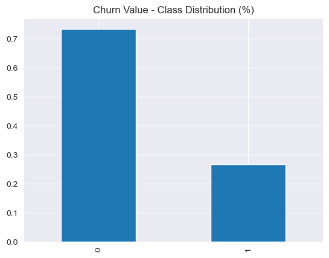

```python
df['Churn Value'].value_counts(normalize=True).plot(kind='bar', title='Churn Value - Class Distribution (%)')
plt.show()
```

```python
df['Churn Value'].mean()
```

```
0.2653698707936959
```

The company lost almost **27%** of customers last month!

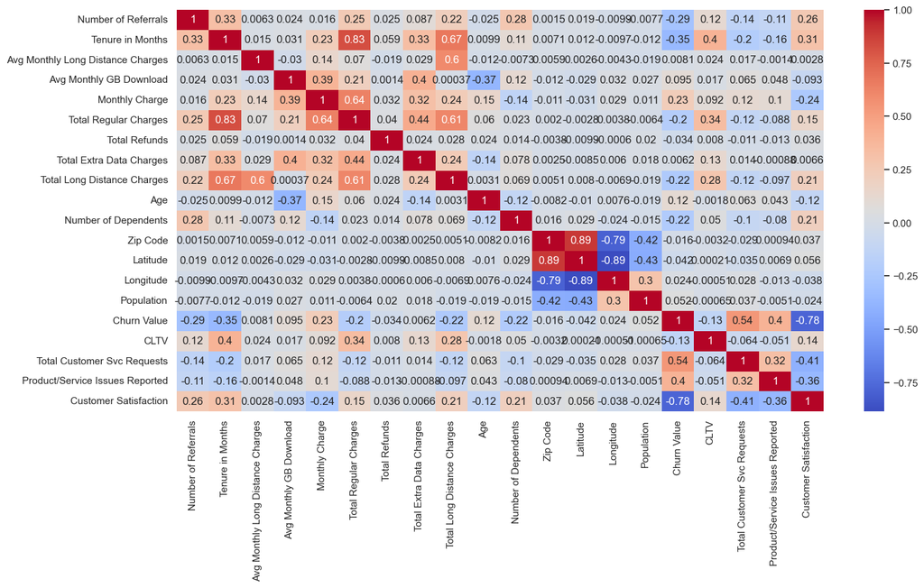

```python
sns.set(rc = {'figure.figsize':(16,8)})
sns.heatmap(df.corr(), annot = True, fmt='.2g',cmap= 'coolwarm')
```

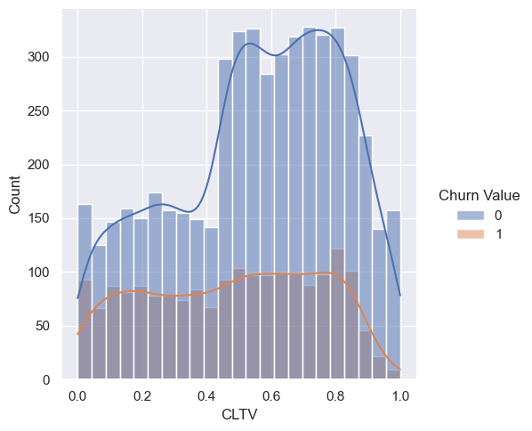

```python
sns.displot(data=df, x="CLTV", hue="Churn Value", kde=True)
```

Let’s look at the relationship between **numerical** and **categorical** variables: In our case, this would allow us to answer questions like "Are churned customers likely to get charged more?", "When do customers churn?", or "Are under 30 customers more likely to churn?".

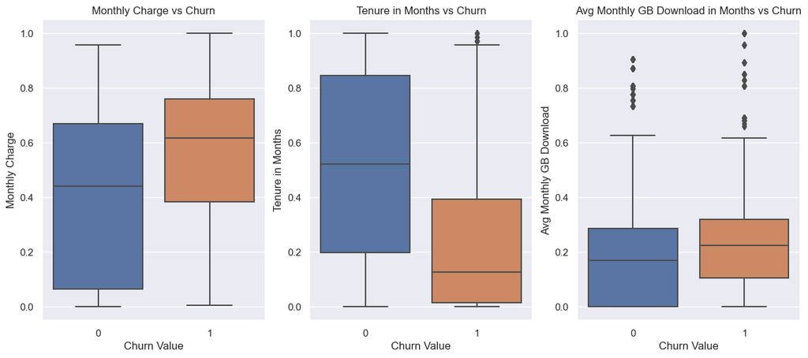

```python
# Numerical variables
fig, axes = plt.subplots(nrows=1, ncols=3, figsize=(15, 6))

## Are churned customers likely to get charged more?
plt.subplot(1,3,1)
sns.boxplot(x=df['Churn Value'], y=df['Monthly Charge'])
plt.title('Monthly Charge vs Churn')

## When do customers churn?
plt.subplot(1,3,2)
sns.boxplot(x=df['Churn Value'], y=df['Tenure in Months'])
plt.title('Tenure in Months vs Churn')

## Are churned customers likely to have a higher avg GB download?
plt.subplot(1,3,3)
sns.boxplot(x=df['Churn Value'], y=df['Avg Monthly GB Download'])
plt.title('Avg Monthly GB Download in Months vs Churn')
plt.show()
```

```python
df.groupby(['Churn Value'])['Monthly Charge'].mean()
```

```
Churn Value
0    0.410317
1    0.563937
Name: Monthly Charge, dtype: float64
```

We can clearly see from this that monthly charges for churning customers are higher, while tenure is much lower. The average montly GB download is also higher for churning customers - this is unexpected.

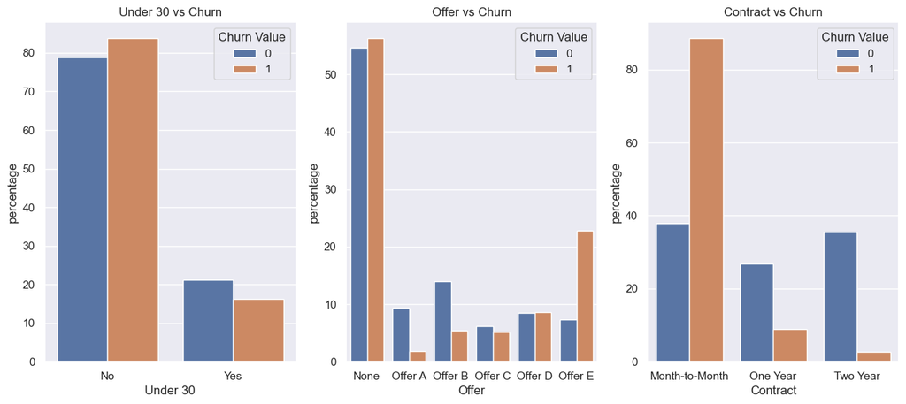

```python
# Categorical variables
fig, axes = plt.subplots(nrows=1, ncols=3, figsize=(15, 6))

## Are Under 30 more likely to churn?
plt.subplot(1,3,1)
counts = (df.groupby(['Churn Value'])['Under 30']
  .value_counts(normalize=True)
  .rename('percentage')
  .mul(100)
  .reset_index())

counts.columns = ["Churn Value", "Under 30", "percentage"]

plot = sns.barplot(x="Under 30", y="percentage", hue="Churn Value", data=counts).set_title('Under 30 vs Churn')

## What service do churned customers have?
plt.subplot(1,3,2)
counts = (df.groupby(['Churn Value'])['Offer']
  .value_counts(normalize=True)
  .rename('percentage')
  .mul(100)
  .reset_index())


counts.columns = ["Churn Value", "Offer", "percentage"]


plot = sns.barplot(x="Offer", y="percentage", hue="Churn Value", data=counts).set_title('Offer vs Churn')

## What type of contract do churned customers have?
plt.subplot(1,3,3)
counts = (df.groupby(['Churn Value'])['Contract']
  .value_counts(normalize=True)
  .rename('percentage')
  .mul(100)
  .reset_index())

counts.columns = ["Churn Value", "Contract", "percentage"]


plot = sns.barplot(x="Contract", y="percentage", hue="Churn Value", data=counts).set_title('Contract vs Churn')
```

```python
df.groupby(['Under 30'])['Monthly Charge'].mean()
```

```
Under 30
No     0.457823
Yes    0.423937
Name: Monthly Charge, dtype: float64
```

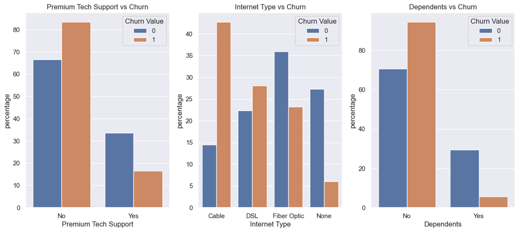

```python
# Categorical variables
fig, axes = plt.subplots(nrows=1, ncols=3, figsize=(15, 6))

## Are churned customers likely to receive tech support?
plt.subplot(1,3,1)
counts = (df.groupby(['Churn Value'])['Premium Tech Support']
  .value_counts(normalize=True)
  .rename('percentage')
  .mul(100)
  .reset_index())

counts.columns = ["Churn Value", "Premium Tech Support", "percentage"]


plot = sns.barplot(x="Premium Tech Support", y="percentage", hue="Churn Value", data=counts).set_title('Premium Tech Support vs Churn')


## Are churned customers likely to have fiber connection?
plt.subplot(1,3,2)
counts = (df.groupby(['Churn Value'])['Internet Type']
  .value_counts(normalize=True)
  .rename('percentage')
  .mul(100)
  .reset_index())


counts.columns = ["Churn Value", "Internet Type", "percentage"]


plot = sns.barplot(x="Internet Type", y="percentage", hue="Churn Value", data=counts).set_title('Internet Type vs Churn')

## Are churned customers likely to have dependents?
plt.subplot(1,3,3)
counts = (df.groupby(['Churn Value'])['Dependents']
  .value_counts(normalize=True)
  .rename('percentage')
  .mul(100)
  .reset_index())


counts.columns = ["Churn Value", "Dependents", "percentage"]


plot = sns.barplot(x="Dependents", y="percentage", hue="Churn Value", data=counts).set_title('Dependents vs Churn')
```

Also the ones receiving premium tech support are less likely to churn compared to those that do. The ones that contracted Fiber are less likely to churn compared to those with DSL. The `Dependents` feature also plays a role in the churn value.

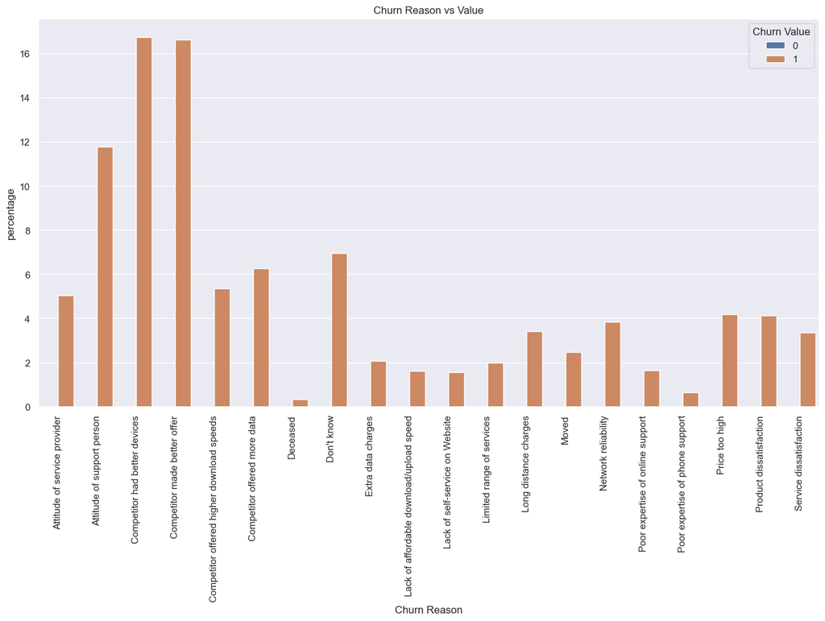

```python
counts = (df.groupby(['Churn Value'])['Churn Reason']
  .value_counts(normalize=True)
  .rename('percentage')
  .mul(100)
  .reset_index())

counts.columns = ["Churn Value", "Churn Reason", "percentage"]


plot = sns.barplot(x="Churn Reason", y="percentage", hue="Churn Value", data=counts).set_title('Churn Reason vs Value')
plt.xticks(rotation=90)
plt.show()
```

The main churn reason is relatable to **competitors**. Seems that competitors are offering better service - better devices or offers.

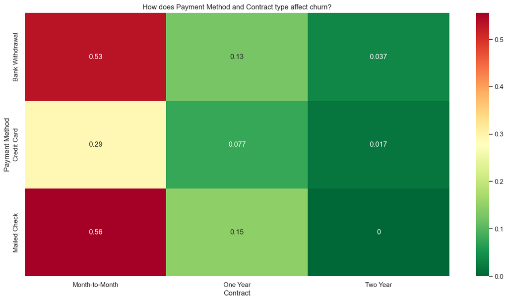

```python
# How does Payment Method and Contract type affect churn?
## Create pivot table
result = pd.pivot_table(data=df, index='Payment Method', columns='Contract',values='Churn Value')
## create heat map of education vs marital vs response_rate
sns.heatmap(result, annot=True, cmap = 'RdYlGn_r').set_title('How does Payment Method and Contract type affect churn?')
plt.show()
```

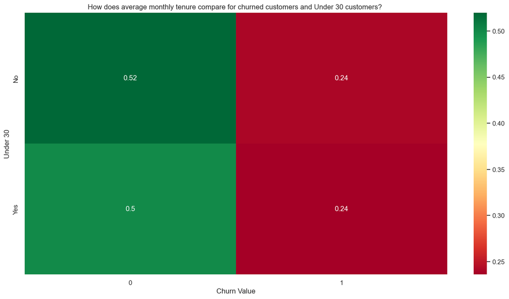

```python
# How does tenure compare for churned customers and senior citizen?
result = pd.pivot_table(data=df, columns=['Churn Value'], index=['Under 30'],values='Tenure in Months')
sns.heatmap(result, annot=True, cmap = 'RdYlGn').set_title('How does average monthly tenure compare for churned customers and Under 30 customers? ')
plt.show()
```

### Conclusions from EDA

Now that we have a better understanding of what’s going on in our data, we can already draw a few conclusions:

```python
df['Churn Value'].mean()
```

```
0.2653698707936959
```

The company lost almost 27% of customers last month! Did the `Offer` help in preventing churn?

```python
dffo = df[["Churn Value", "Offer"] + num_cols]
```

Using only numerical columns...

```python
dffo.shape
```

```
(7043, 21)
```

```python
dffo.info()
```

```
<class 'pandas.core.frame.DataFrame'>
RangeIndex: 7043 entries, 0 to 7042
Data columns (total 21 columns):
 #   Column                             Non-Null Count  Dtype
---  ------                             --------------  -----
 0   Churn Value                        7043 non-null   int64
 1   Offer                              7043 non-null   category
 2   Number of Referrals                7043 non-null   float64
 3   Tenure in Months                   7043 non-null   float64
 4   Avg Monthly Long Distance Charges  7043 non-null   float64
 5   Avg Monthly GB Download            7043 non-null   float64
 6   Monthly Charge                     7043 non-null   float64
 7   Total Regular Charges              7043 non-null   float64
 8   Total Refunds                      7043 non-null   float64
 9   Total Extra Data Charges           7043 non-null   float64
 10  Total Long Distance Charges        7043 non-null   float64
 11  Age                                7043 non-null   float64
 12  Number of Dependents               7043 non-null   float64
 13  Zip Code                           7043 non-null   float64
 14  Latitude                           7043 non-null   float64
 15  Longitude                          7043 non-null   float64
 16  Population                         7043 non-null   float64
 17  CLTV                               7043 non-null   float64
 18  Total Customer Svc Requests        7043 non-null   float64
 19  Product/Service Issues Reported    7043 non-null   float64
 20  Customer Satisfaction              1834 non-null   float64
dtypes: category(1), float64(19), int64(1)
memory usage: 1.1 MB
```

The company lost almost *27%* of customers last month! Did the `Offer` help in preventing churn?

We want to compare the churn frequency of customers that received different types of `Offer` with the churn frequency. Since we have different `Offer`, the difference-in-means estimator is an unbiased estimator for the [average treatment effect (ATE)](https://en.wikipedia.org/wiki/Average_treatment_effect) of the `Offer` on `churn`.

$$ ATE = \mathbb{E} \Big[ Y \ \Big| \ W = 1 \Big] - \mathbb{E} \Big[ Y \ \Big| \ W = 0 \Big] $$

We compute the difference-in-means estimate by linear regression. We also include other covariates to improve the efficiency of the estimator.

To do so, we first need to encode the `Offer`into different columns - using `pd.get_dummies`

```python
offer_dummies = pd.get_dummies(dffo[["Offer"]])

dffo = dffo.join(offer_dummies)
dffo = dffo.drop(columns=["Offer"])
```

```python
dffo.head()
```

|  | Churn Value | Number of Referrals | Tenure in Months | Avg Monthly Long Distance Charges | Avg Monthly GB Download | Monthly Charge | Total Regular Charges | Total Refunds | Total Extra Data Charges | Total Long Distance Charges | ... | CLTV | Total Customer Svc Requests | Product/Service Issues Reported | Customer Satisfaction | Offer_None | Offer_Offer A | Offer_Offer B | Offer_Offer C | Offer_Offer D | Offer_Offer E |
| --- | --- | --- | --- | --- | --- | --- | --- | --- | --- | --- | --- | --- | --- | --- | --- | --- | --- | --- | --- | --- | --- |
| 0 | 1 | 0.000000 | 0.000000 | 0.000000 | 0.095745 | 0.219261 | 0.002406 | 0.000000 | 0.000000 | 0.000000 | ... | 0.762731 | 0.555556 | 0.000000 | NaN | 1 | 0 | 0 | 0 | 0 | 0 |
| 1 | 1 | 0.090909 | 0.098592 | 0.977195 | 0.202128 | 0.625999 | 0.070909 | 0.000000 | 0.018527 | 0.109630 | ... | 0.733600 | 0.555556 | 0.000000 | NaN | 0 | 0 | 0 | 0 | 0 | 1 |
| 2 | 1 | 0.000000 | 0.239437 | 0.226645 | 0.606383 | 0.772822 | 0.200063 | 0.916047 | 0.000000 | 0.057211 | ... | 0.261508 | 0.111111 | 0.000000 | NaN | 0 | 0 | 0 | 0 | 1 | 0 |
| 3 | 1 | 0.090909 | 0.338028 | 0.395279 | 0.138298 | 0.803079 | 0.287988 | 0.269733 | 0.050486 | 0.138580 | ... | 0.741383 | 0.111111 | 0.166667 | 0.25 | 0 | 0 | 0 | 1 | 0 | 0 |
| 4 | 1 | 0.090909 | 0.507042 | 0.126625 | 0.159574 | 0.584829 | 0.328796 | 0.000000 | 0.066389 | 0.065702 | ... | 0.175673 | 0.111111 | 0.000000 | 0.25 | 0 | 0 | 0 | 1 | 0 | 0 |

5 rows × 26 columns

We can define the monthly revenue by customer as all the charges (regular + extra + long distance), removing the refunds.

```python
dffo["revenue"] = dffo["Total Regular Charges"] + dffo["Total Extra Data Charges"] + dffo["Total Long Distance Charges"] - dffo["Total Refunds"]
dffo["extra_charges"] = dffo["revenue"] - dffo["Total Regular Charges"]
dffo["total_charges_only"] = (dffo["revenue"] > dffo["Total Regular Charges"] ).astype(int)
```

```python
extra_features = ['revenue', 'extra_charges', 'total_charges_only']
```

```python
dffo = dffo.fillna(0)
```

We will try to understand if there is a data-informed way to split different `Offer` to different customers that is profitable. In particular, we will ccompare different data-informed targeting policies with the objective of increasing revenue.

```python
Y = ['Churn Value', 'revenue']
W = ["Offer_None", "Offer_Offer A", "Offer_Offer B", "Offer_Offer C", "Offer_Offer D", "Offer_Offer E"]
X = list(set(num_cols) - set(Y) - set(W))
```

```python
X
```

```
['CLTV',
 'Avg Monthly GB Download',
 'Product/Service Issues Reported',
 'Tenure in Months',
 'Population',
 'Number of Dependents',
 'Total Refunds',
 'Latitude',
 'Total Regular Charges',
 'Total Customer Svc Requests',
 'Longitude',
 'Total Extra Data Charges',
 'Monthly Charge',
 'Total Long Distance Charges',
 'Avg Monthly Long Distance Charges',
 'Zip Code',
 'Customer Satisfaction',
 'Number of Referrals',
 'Age']
```

```python
W
```

```
['Offer_None',
 'Offer_Offer A',
 'Offer_Offer B',
 'Offer_Offer C',
 'Offer_Offer D',
 'Offer_Offer E']
```

```python
x = dffo[X + W + extra_features]
y = dffo["Churn Value"]
```

```python
x = sm.add_constant(x)
est = sm.OLS(y, x).fit()
est.summary()
```

OLS Regression Results

| Dep. Variable: | Churn Value | R-squared: | 0.517 |
| --- | --- | --- | --- |
| Model: | OLS | Adj. R-squared: | 0.515 |
| Method: | Least Squares | F-statistic: | 300.6 |
| Date: | Tue, 05 Sep 2023 | Prob (F-statistic): | 0.00 |
| Time: | 16:08:57 | Log-Likelihood: | -1671.9 |
| No. Observations: | 7043 | AIC: | 3396. |
| Df Residuals: | 7017 | BIC: | 3574. |
| Df Model: | 25 |  |  |
| Covariance Type: | nonrobust |  |  |

|  | coef | std err | t | P>\|t\| | [0.025 | 0.975] |
| --- | --- | --- | --- | --- | --- | --- |
| const | 0.0621 | 0.033 | 1.895 | 0.058 | -0.002 | 0.126 |
| CLTV | 0.0106 | 0.015 | 0.695 | 0.487 | -0.019 | 0.041 |
| Avg Monthly GB Download | -0.0310 | 0.022 | -1.395 | 0.163 | -0.075 | 0.013 |
| Product/Service Issues Reported | 0.6697 | 0.033 | 20.373 | 0.000 | 0.605 | 0.734 |
| Tenure in Months | -0.0046 | 0.031 | -0.149 | 0.882 | -0.065 | 0.056 |
| Population | 0.0628 | 0.021 | 3.012 | 0.003 | 0.022 | 0.104 |
| Number of Dependents | -0.2632 | 0.037 | -7.109 | 0.000 | -0.336 | -0.191 |
| Total Refunds | -0.0070 | 0.026 | -0.268 | 0.788 | -0.058 | 0.044 |
| Latitude | -0.1509 | 0.043 | -3.538 | 0.000 | -0.235 | -0.067 |
| Total Regular Charges | -0.4800 | 0.030 | -15.808 | 0.000 | -0.540 | -0.420 |
| Total Customer Svc Requests | 1.0560 | 0.026 | 41.318 | 0.000 | 1.006 | 1.106 |
| Longitude | -0.0680 | 0.038 | -1.790 | 0.073 | -0.142 | 0.006 |
| Total Extra Data Charges | 0.2522 | 0.033 | 7.623 | 0.000 | 0.187 | 0.317 |
| Monthly Charge | 0.5813 | 0.025 | 23.098 | 0.000 | 0.532 | 0.631 |
| Total Long Distance Charges | 0.0192 | 0.030 | 0.643 | 0.520 | -0.039 | 0.078 |
| Avg Monthly Long Distance Charges | -0.0732 | 0.020 | -3.594 | 0.000 | -0.113 | -0.033 |
| Zip Code | 0.0981 | 0.027 | 3.586 | 0.000 | 0.044 | 0.152 |
| Customer Satisfaction | -0.2440 | 0.014 | -17.747 | 0.000 | -0.271 | -0.217 |
| Number of Referrals | -0.1610 | 0.015 | -10.892 | 0.000 | -0.190 | -0.132 |
| Age | 0.0679 | 0.016 | 4.369 | 0.000 | 0.037 | 0.098 |
| Offer_None | 0.0172 | 0.008 | 2.171 | 0.030 | 0.002 | 0.033 |
| Offer_Offer A | 0.0460 | 0.016 | 2.953 | 0.003 | 0.015 | 0.077 |
| Offer_Offer B | -0.0046 | 0.012 | -0.374 | 0.708 | -0.029 | 0.020 |
| Offer_Offer C | -0.0437 | 0.015 | -3.002 | 0.003 | -0.072 | -0.015 |
| Offer_Offer D | -0.0407 | 0.013 | -3.179 | 0.001 | -0.066 | -0.016 |
| Offer_Offer E | 0.0879 | 0.013 | 6.926 | 0.000 | 0.063 | 0.113 |
| revenue | -0.2016 | 0.016 | -12.667 | 0.000 | -0.233 | -0.170 |
| extra_charges | 0.2784 | 0.019 | 14.760 | 0.000 | 0.241 | 0.315 |
| total_charges_only | -0.0213 | 0.017 | -1.226 | 0.220 | -0.055 | 0.013 |

| Omnibus: | 503.880 | Durbin-Watson: | 1.007 |
| --- | --- | --- | --- |
| Prob(Omnibus): | 0.000 | Jarque-Bera (JB): | 624.456 |
| Skew: | 0.681 | Prob(JB): | 2.52e-136 |
| Kurtosis: | 3.525 | Cond. No. | 7.33e+15 |

Notes:  
[1] Standard Errors assume that the covariance matrix of the errors is correctly specified.  
[2] The smallest eigenvalue is 6.14e-28. This might indicate that there are  
strong multicollinearity problems or that the design matrix is singular.

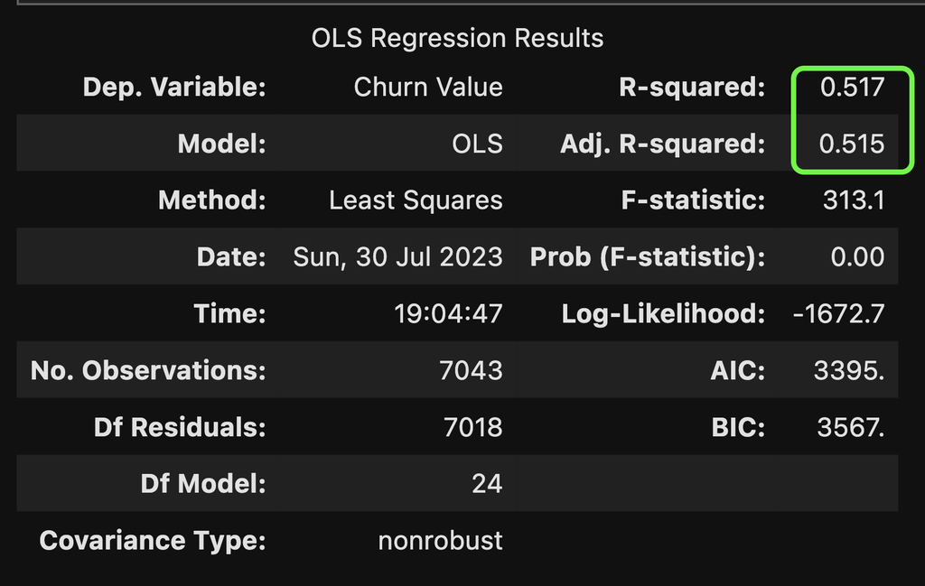

```python
display.Image("./img/model.png")
```

Good model given its a linear regression + 7k rows - Rsquared 0.517

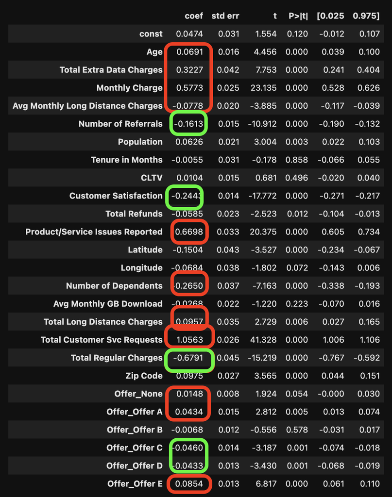

```python
display.Image("./img/all.png")
```

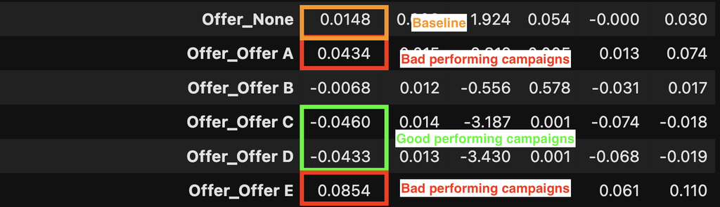

```python
display.Image("./img/campaigns.png")
```

It looks like the `Offer_Offer_C` and `Offer_Offer_D` decreased churn by around *4%* percentage points. The worst offers that we have, impacting negativelly churn are `Offer_Offer_A` and `Offer_Offer_E`. `None` offer with a negative impact on churn but overall *1%* impact.

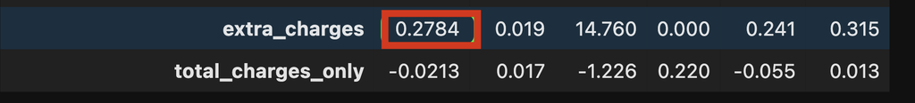

```python
display.Image("./img/extra.png")
```

No surprise, extra charges have a **negative** impact on churn

# Model Building/Validation/Tuning

We use gradient-boosted tree models from the `lightgbm` library

```python
x = df.drop(columns=["Churn Value", "CLTV", "Churn Category", 'Churn Reason',
                     "Total Customer Svc Requests", "Product/Service Issues Reported",
                     "Customer Satisfaction"])
y = df[["Churn Value"]]
```

```python
# split the dataset into the training set and test set
from sklearn.model_selection import train_test_split
X_train, X_test, y_train, y_test = train_test_split(x, y, test_size = 0.3, random_state = 0)
```

```python
import lightgbm as lgb
clf = lgb.LGBMClassifier()
clf.fit(X_train, y_train)
```

```
LGBMClassifier()
```

```python
y_pred=clf.predict(X_test)
y_pred_proba=clf.predict_proba(X_test)[:,1]
```

```python
y_test_plot = y_test.reset_index()
churn_idx = y_test_plot[y_test_plot["Churn Value"] == 1].index
no_churn_idx = y_test_plot[y_test_plot["Churn Value"] == 0].index
```

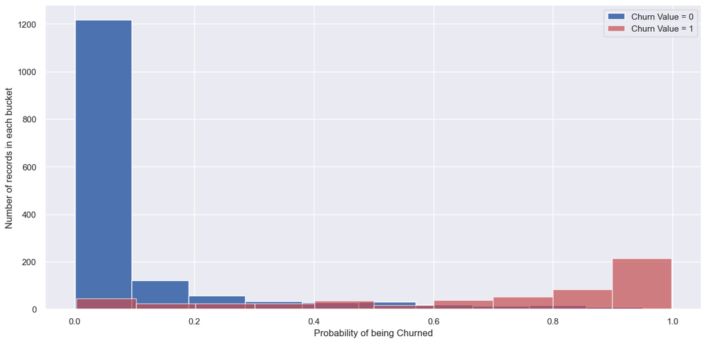

```python
plt.figure(figsize=(15,7))
plt.hist(y_pred_proba[no_churn_idx], bins=10, label='Churn Value = 0')
plt.hist(y_pred_proba[churn_idx], bins=10, label='Churn Value = 1', alpha=0.7, color='r')
plt.xlabel('Probability of being Churned')
plt.ylabel('Number of records in each bucket')
plt.tick_params(axis='both', pad=5)
plt.legend()
plt.show()
```

```python
# view accuracy
accuracy=accuracy_score(y_pred, y_test)
print('LightGBM Model accuracy score: {0:0.4f}'.format(accuracy_score(y_test, y_pred)))
```

```
LightGBM Model accuracy score: 0.8859
```

##### Check for Overfitting

```python
print('Training set score: {:.4f}'.format(clf.score(X_train, y_train)))
print('Test set score: {:.4f}'.format(clf.score(X_test, y_test)))
```

```
Training set score: 0.9915
Test set score: 0.8859
```

We were able to predict churn for test data - in practice this could be for example new customers - with an accuracy of almost **89%**

```
True Positives(TP) =  1467
True Negatives(TN) =  405
False Positives(FP) =  88
False Negatives(FN) =  153
```

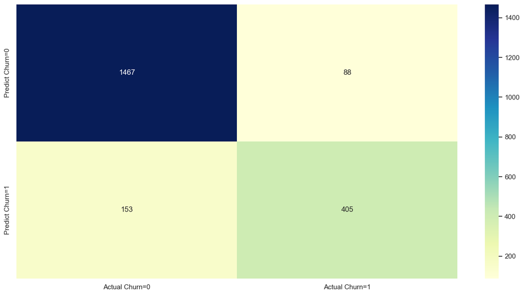

```python
cm = confusion_matrix(y_test, y_pred)
cm_matrix = pd.DataFrame(data=cm, columns=['Actual Churn=0', 'Actual Churn=1'],
                                    index=['Predict Churn=0', 'Predict Churn=1'])

sns.heatmap(cm_matrix, annot=True, fmt='d', cmap='YlGnBu')

print('\nTrue Positives(TP) = ', cm[0,0])
print('True Negatives(TN) = ', cm[1,1])
print('False Positives(FP) = ', cm[0,1])
print('False Negatives(FN) = ', cm[1,0])
print('\n')
```

```python
print(classification_report(y_test, y_pred))
```

```
              precision    recall  f1-score   support

           0       0.91      0.94      0.92      1555
           1       0.82      0.73      0.77       558

    accuracy                           0.89      2113
   macro avg       0.86      0.83      0.85      2113
weighted avg       0.88      0.89      0.88      2113
```

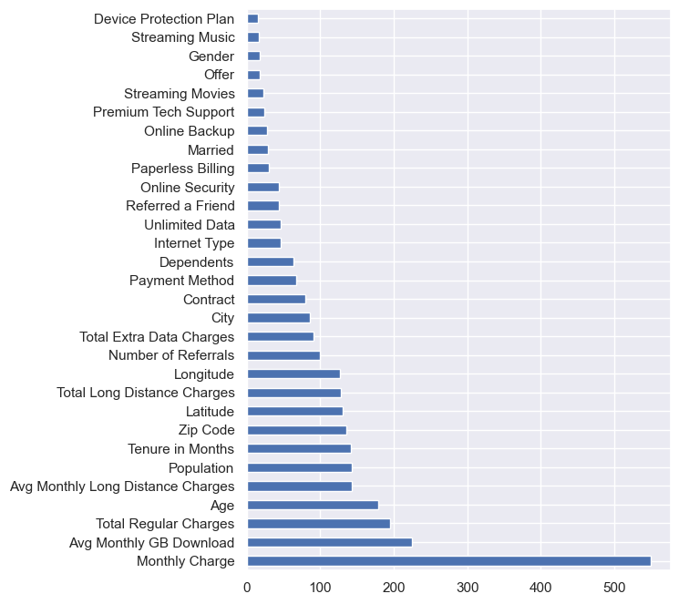

```python
feat_imp = pd.Series(clf.feature_importances_, index=x.columns)
feat_imp.nlargest(30).plot(kind='barh', figsize=(6,8))
plt.show()
```

```python
explainer = shap.TreeExplainer(clf)
shap_values = explainer.shap_values(X_train)
```

```python
shap.force_plot(explainer.expected_value[1], shap_values[1][0,:], X_train.iloc[0,:])
```

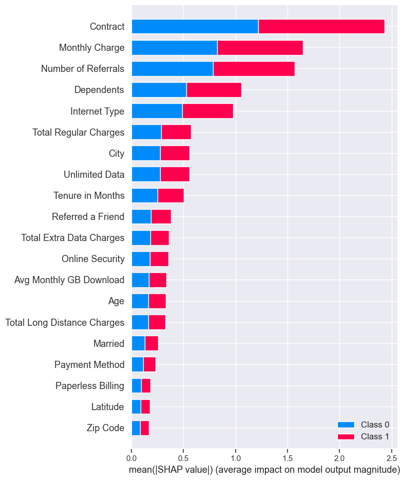

```python
shap.summary_plot(shap_values, X_train)
```

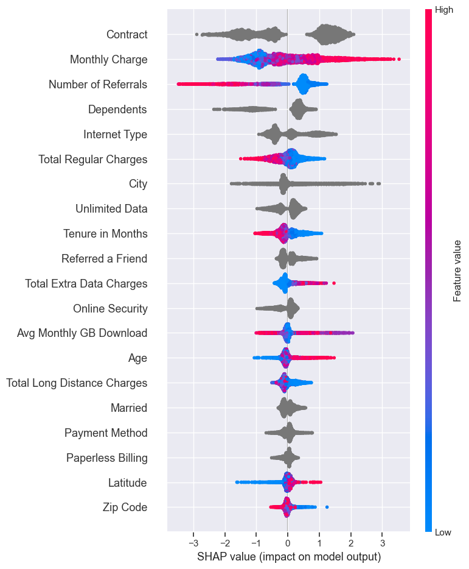

```python
shap.summary_plot(shap_values[1], X_train)
```

#### Hyperparameter Tuning

```python
import optuna
from optuna.integration import LightGBMPruningCallback

def objective(trial, X, y):
    param_grid = {
        # "device_type": trial.suggest_categorical("device_type", ['gpu']),
        "n_estimators": trial.suggest_categorical("n_estimators", [10000]),
        "learning_rate": trial.suggest_float("learning_rate", 0.01, 0.3),
        "num_leaves": trial.suggest_int("num_leaves", 20, 3000, step=20),
        "max_depth": trial.suggest_int("max_depth", 3, 12),
        "min_data_in_leaf": trial.suggest_int("min_data_in_leaf", 200, 10000, step=100),
        "lambda_l1": trial.suggest_int("lambda_l1", 0, 100, step=5),
        "lambda_l2": trial.suggest_int("lambda_l2", 0, 100, step=5),
        "min_gain_to_split": trial.suggest_float("min_gain_to_split", 0, 15),
        "bagging_fraction": trial.suggest_float(
            "bagging_fraction", 0.2, 0.95, step=0.1
        ),
        "bagging_freq": trial.suggest_categorical("bagging_freq", [1]),
        "feature_fraction": trial.suggest_float(
            "feature_fraction", 0.2, 0.95, step=0.1
        ),
    }

    cv = StratifiedKFold(n_splits=3, shuffle=True, random_state=24)

    cv_scores = []
    for idx, (train_idx, test_idx) in enumerate(cv.split(X, y)):
        X_train, X_test = X.iloc[train_idx], X.iloc[test_idx]
        y_train, y_test = y.iloc[train_idx], y.iloc[test_idx]

        model = lgb.LGBMClassifier(objective="binary", **param_grid)
        model.fit(
            X_train,
            y_train,
            eval_set=[(X_test, y_test)],
            eval_metric="binary_logloss",
            early_stopping_rounds=100,
            callbacks=[
                LightGBMPruningCallback(trial, "binary_logloss")
            ],
        )

        preds = model.predict_proba(X_test)

        cv_scores.append(log_loss(y_test, preds))

    return np.mean(np.array(cv_scores))
```

```python
study = optuna.create_study(direction="minimize", study_name="LGBM Classifier")
func = lambda trial: objective(trial, x, y)
study.optimize(func, n_trials=20)
```

[output not shown]

[output not shown]

[output not shown]

[output not shown]

[output not shown]

[output not shown]

[output not shown]

[output not shown]

[output not shown]

[output not shown]

[output not shown]

[output not shown]

[output not shown]

[output not shown]

[output not shown]

[output not shown]

[output not shown]

[output not shown]

[output not shown]

[output not shown]

[output not shown]

[output not shown]

[output not shown]

[output not shown]

[output not shown]

[output not shown]

[output not shown]

[output not shown]

[output not shown]

[output not shown]

[output not shown]

[output not shown]

```python
print(f"\tBest value (rmse): {study.best_value:.5f}")
print(f"\tBest params:")

for key, value in study.best_params.items():
    print(f"\t\t{key}: {value}")
```

```
	Best value (rmse): 0.38382
	Best params:
		n_estimators: 10000
		learning_rate: 0.12124166914034631
		num_leaves: 600
		max_depth: 5
		min_data_in_leaf: 200
		lambda_l1: 30
		lambda_l2: 75
		min_gain_to_split: 6.38946783039192
		bagging_fraction: 0.4
		bagging_freq: 1
		feature_fraction: 0.7
```

# What are the best actions to take based on the model?

First of all, let's define profits *Π* as the net revenue *R* when the customer does not churn *C*. $$ \Pi = R (1-C) $$

Therefore, the overall effect on profits for treated individuals is given by the difference between the profits when treated *Π⁽¹⁾* minus the profits when not treated *Π⁽⁰⁾*.

$$ \tau_{\pi} = R_1 (1 - C_1) - R_0 (1 - C_0) $$

The effect for untreated individuals is zero.

**Policy:** Revenue for non-churned customers.

```python
def evaluate_policy(data, policy):
    data['profits'] = (1 - data["Churn Value"]) * data["revenue"]
    baseline = (1-data["Churn Value"]) * data["revenue"]
    effect = policy(data) * (1-data["Churn Value"]) * (data["revenue"]) - (1-policy(data)) * (1-data["Churn Value"]) * data["revenue"]
    return np.sum(effect - baseline)
```

```python
df["revenue"] = df["Total Regular Charges"] + df["Total Extra Data Charges"] + df["Total Long Distance Charges"] - df["Total Refunds"]
df["extra_charges"] = df["revenue"] - df["Total Regular Charges"]
df["total_charges_only"] = (df["revenue"] > df["Total Regular Charges"] ).astype(int)
```

#### 1. Target Churning Customers

```python
X
```

```
['Zip Code',
 'Monthly Charge',
 'Tenure in Months',
 'Longitude',
 'Population',
 'Total Long Distance Charges',
 'Customer Satisfaction',
 'Avg Monthly Long Distance Charges',
 'Total Customer Svc Requests',
 'Product/Service Issues Reported',
 'Avg Monthly GB Download',
 'Total Extra Data Charges',
 'Number of Referrals',
 'Total Regular Charges',
 'Total Refunds',
 'Age',
 'Latitude',
 'CLTV',
 'Number of Dependents']
```

```python
df_features = df[X]
df_target = df[["Churn Value"]]

# split the dataset into the training set and test set
from sklearn.model_selection import train_test_split
X_train, X_test, y_train, y_test = train_test_split(df_features, df_target, test_size = 0.3, random_state = 0)


import lightgbm as lgb
clf = lgb.LGBMClassifier()
clf.fit(X_train, y_train)
policy_churn = lambda df : (clf.predict_proba(df[X])[:,1] > df["Churn Value"].mean())


evaluate_policy(df, policy_churn)
```

```
-5442.061682564048
```

The policy is not profitable and would lead to an aggregate loss of more than 5442$.

You might think that the problem is the arbitrary threshold, but this is not the case. Below I plot the aggregate effect for all possible policy thresholds.

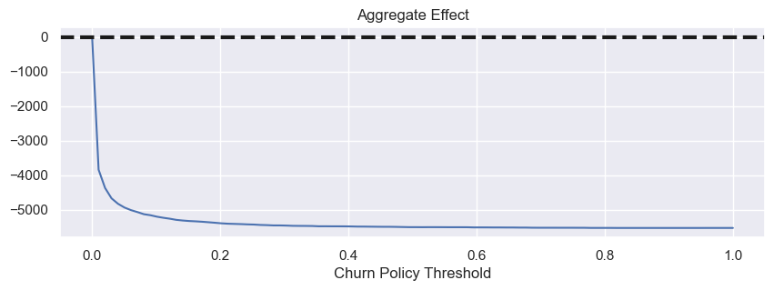

```python
x = np.linspace(0, 1, 100)
y = [evaluate_policy(df, lambda df : (clf.predict_proba(df[X])[:,1] > k)) for k in x]

fig, ax = plt.subplots(figsize=(10, 3))
sns.lineplot(x=x, y=y).set(xlabel='Churn Policy Threshold', title='Aggregate Effect');
ax.axhline(y=0, c='k', lw=3, ls='--');
```

As we can see, at best we can make zero losses when we don't have any churning customer.

The problem is that the fact that a customer is likely to churn does not imply that the features will have any impact on their churn probability. The two measures are not completely unrelated (e.g. we cannot decrease the churning probability of customers that have 0% probability of churning), but they are not the same thing.

#### 2. Target revenue customers

Let's now try a different policy: high-revenue customers. For example, we might change the offer only to the top-10% of customers by revenue. The idea is that, if the policy indeed decreases churn, these are the customers for whom decreasing churn is more profitable.

```python
model_revenue = LGBMRegressor().fit(X=df[X], y=df['revenue'])

policy_revenue = lambda df : (model_revenue.predict(df[X]) > np.quantile(df.revenue, 0.9))
evaluate_policy(df, policy_revenue)
```

```
-3637.075540295698
```

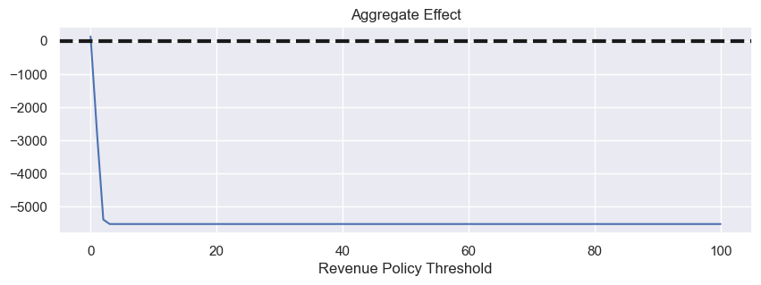

```python
x = np.linspace(0, 100, 100)
y = [evaluate_policy(df, lambda df : (model_revenue.predict(df[X]) > k)) for k in x]

fig, ax = plt.subplots(figsize=(10, 3))
sns.lineplot(x=x, y=y).set(xlabel='Revenue Policy Threshold', title='Aggregate Effect');
ax.axhline(y=0, c='k', lw=3, ls='--');
```

#### 3. Target churn uplift customers

A more sensible approach would be to target customers whose churn probability decreases the most when receiving. We estimate churn uplift using the double-robust estimator, one of the best performing uplift models.

```python
dffo.head()
```

|  | Churn Value | Number of Referrals | Tenure in Months | Avg Monthly Long Distance Charges | Avg Monthly GB Download | Monthly Charge | Total Regular Charges | Total Refunds | Total Extra Data Charges | Total Long Distance Charges | ... | Customer Satisfaction | Offer_None | Offer_Offer A | Offer_Offer B | Offer_Offer C | Offer_Offer D | Offer_Offer E | revenue | extra_charges | total_charges_only |
| --- | --- | --- | --- | --- | --- | --- | --- | --- | --- | --- | --- | --- | --- | --- | --- | --- | --- | --- | --- | --- | --- |
| 0 | 1 | 0.000000 | 0.000000 | 0.000000 | 0.095745 | 0.219261 | 0.002406 | 0.000000 | 0.000000 | 0.000000 | ... | 0.00 | 1 | 0 | 0 | 0 | 0 | 0 | 0.002406 | 0.000000 | 0 |
| 1 | 1 | 0.090909 | 0.098592 | 0.977195 | 0.202128 | 0.625999 | 0.070909 | 0.000000 | 0.018527 | 0.109630 | ... | 0.00 | 0 | 0 | 0 | 0 | 0 | 1 | 0.199066 | 0.128157 | 1 |
| 2 | 1 | 0.000000 | 0.239437 | 0.226645 | 0.606383 | 0.772822 | 0.200063 | 0.916047 | 0.000000 | 0.057211 | ... | 0.00 | 0 | 0 | 0 | 0 | 1 | 0 | -0.658773 | -0.858837 | 0 |
| 3 | 1 | 0.090909 | 0.338028 | 0.395279 | 0.138298 | 0.803079 | 0.287988 | 0.269733 | 0.050486 | 0.138580 | ... | 0.25 | 0 | 0 | 0 | 1 | 0 | 0 | 0.207321 | -0.080666 | 0 |
| 4 | 1 | 0.090909 | 0.507042 | 0.126625 | 0.159574 | 0.584829 | 0.328796 | 0.000000 | 0.066389 | 0.065702 | ... | 0.25 | 0 | 0 | 0 | 1 | 0 | 0 | 0.460887 | 0.132091 | 1 |

5 rows × 29 columns

```python
df.iloc[7039]
```

```
Customer ID                            6840-RESVB
Referred a Friend                             Yes
Number of Referrals                      0.090909
Tenure in Months                         0.323944
Offer                                     Offer C
Phone Service                                 Yes
Avg Monthly Long Distance Charges        0.721144
Multiple Lines                                Yes
Internet Service                              Yes
Internet Type                                 DSL
Avg Monthly GB Download                  0.255319
Online Security                               Yes
Online Backup                                  No
Device Protection Plan                        Yes
Premium Tech Support                          Yes
Streaming TV                                  Yes
Streaming Movies                              Yes
Streaming Music                               Yes
Unlimited Data                                Yes
Contract                                 One Year
Paperless Billing                             Yes
Payment Method                       Mailed Check
Monthly Charge                           0.634813
Total Regular Charges                    0.227521
Total Refunds                            0.968668
Total Extra Data Charges                      0.0
Total Long Distance Charges              0.242712
Gender                                       Male
Age                                      0.311475
Under 30                                       No
Senior Citizen                                 No
Married                                       Yes
Dependents                                    Yes
Number of Dependents                     0.222222
City                                     Adelanto
Zip Code                                 0.374045
Latitude                                 0.224529
Longitude                                0.669259
Population                               0.180187
Churn Value                                     0
CLTV                                     0.030465
Churn Category                                NaN
Churn Reason                                  NaN
Total Customer Svc Requests              0.222222
Product/Service Issues Reported               0.0
Customer Satisfaction                         NaN
revenue                                 -0.498435
extra_charges                           -0.725956
total_charges_only                              0
profits                                 -0.498435
Name: 7039, dtype: object
```

```python
df["Customer Satisfaction"] = df["Customer Satisfaction"].fillna(value=0)
```

```python
X_cs = df.drop(columns=["Customer ID", "Churn Value", "CLTV", "Churn Category", 'Churn Reason',
                     "Total Customer Svc Requests", "Product/Service Issues Reported",
                     "Customer Satisfaction"])
y_cs = df[["Churn Value"]]
```

```python
X_cs.info()
```

```
<class 'pandas.core.frame.DataFrame'>
RangeIndex: 7043 entries, 0 to 7042
Data columns (total 42 columns):
 #   Column                             Non-Null Count  Dtype
---  ------                             --------------  -----
 0   Referred a Friend                  7043 non-null   category
 1   Number of Referrals                7043 non-null   float64
 2   Tenure in Months                   7043 non-null   float64
 3   Offer                              7043 non-null   category
 4   Phone Service                      7043 non-null   category
 5   Avg Monthly Long Distance Charges  7043 non-null   float64
 6   Multiple Lines                     7043 non-null   category
 7   Internet Service                   7043 non-null   category
 8   Internet Type                      7043 non-null   category
 9   Avg Monthly GB Download            7043 non-null   float64
```

[output cut: 34 more lines]

```python
num_cols[:-4]
```

```
['Number of Referrals',
 'Tenure in Months',
 'Avg Monthly Long Distance Charges',
 'Avg Monthly GB Download',
 'Monthly Charge',
 'Total Regular Charges',
 'Total Refunds',
 'Total Extra Data Charges',
 'Total Long Distance Charges',
 'Age',
 'Number of Dependents',
 'Zip Code',
 'Latitude',
 'Longitude',
 'Population']
```

We import the doubly-robust learner from econml, a Microsoft library.

```python
from econml.dr import DRLearner
```

```python
DR_learner_churn_none = DRLearner(model_regression=LGBMRegressor(random_state=24),
                               model_propensity=LGBMClassifier(random_state=24),
                               model_final=LGBMRegressor(random_state=24))

model_none = DR_learner_churn_none.fit(df['Churn Value'], dffo["Offer_None"], X=X_cs[num_cols[:-4]])
policy_churn_offer_none = lambda df : model_none.effect(X_cs[num_cols[:-4]]) < - np.mean(df["Churn Value"])
evaluate_policy(df, policy_churn_offer_none)
```

```
-5291.90158117779
```

```python
DR_learner_churn_a = DRLearner(model_regression=LGBMRegressor(random_state=24),
                               model_propensity=LGBMClassifier(random_state=24),
                               model_final=LGBMRegressor(random_state=24))

model_a = DR_learner_churn_a.fit(df['Churn Value'], dffo["Offer_Offer A"], X=X_cs[num_cols[:-4]])
policy_churn_offer_a = lambda df : model_a.effect(X_cs[num_cols[:-4]]) < - np.mean(df["Churn Value"])
evaluate_policy(df, policy_churn_offer_a)
```

```
-5065.074069506904
```

The problem is that we haven't considered the cost of the policy. In fact, decreasing the churn probability is only profitable for high-revenue customers. Take the extreme case: avoiding churn of a customer that does not generate any revenue is not worth any intervention.

Let's see for other offers:

```python
DR_learner_churn_b = DRLearner(model_regression=LGBMRegressor(random_state=24),
                               model_propensity=LGBMClassifier(random_state=24),
                               model_final=LGBMRegressor(random_state=24))

model_b = DR_learner_churn_b.fit(df['Churn Value'], dffo["Offer_Offer B"], X=X_cs[num_cols[:-4]])
policy_churn_offer_b = lambda df : model_b.effect(X_cs[num_cols[:-4]]) < - np.mean(df["Churn Value"])
evaluate_policy(df, policy_churn_offer_b)
```

```
-4988.62148221807
```

```python
DR_learner_churn_c = DRLearner(model_regression=LGBMRegressor(random_state=24),
                               model_propensity=LGBMClassifier(random_state=24),
                               model_final=LGBMRegressor(random_state=24))

model_c = DR_learner_churn_c.fit(df['Churn Value'], dffo["Offer_Offer C"], X=X_cs[num_cols[:-4]])
policy_churn_offer_c = lambda df : model_c.effect(X_cs[num_cols[:-4]]) < - np.mean(df["Churn Value"])
evaluate_policy(df, policy_churn_offer_c)
```

```
-4782.621798348411
```

```python
DR_learner_churn_d = DRLearner(model_regression=LGBMRegressor(random_state=24),
                               model_propensity=LGBMClassifier(random_state=24),
                               model_final=LGBMRegressor(random_state=24))

model_d = DR_learner_churn_d.fit(df['Churn Value'], dffo["Offer_Offer D"], X=X_cs[num_cols[:-4]])
policy_churn_offer_d = lambda df : model_d.effect(X_cs[num_cols[:-4]]) < - np.mean(df["Churn Value"])
evaluate_policy(df, policy_churn_offer_d)
```

```
-5011.582586803156
```

```python
DR_learner_churn_e = DRLearner(model_regression=LGBMRegressor(random_state=24),
                               model_propensity=LGBMClassifier(random_state=24),
                               model_final=LGBMRegressor(random_state=24))

model_e = DR_learner_churn_e.fit(df['Churn Value'], dffo["Offer_Offer E"], X=X_cs[num_cols[:-4]])
policy_churn_offer_e = lambda df : model_e.effect(X_cs[num_cols[:-4]]) < - np.mean(df["Churn Value"])
evaluate_policy(df, policy_churn_offer_e)
```

```
-5351.082139923398
```

it seems that not a single 1 offer has a positive effect in terms of revenue!

the cost of doing nothing, meaning `Offer_None`, has a bad -1% of revenue!

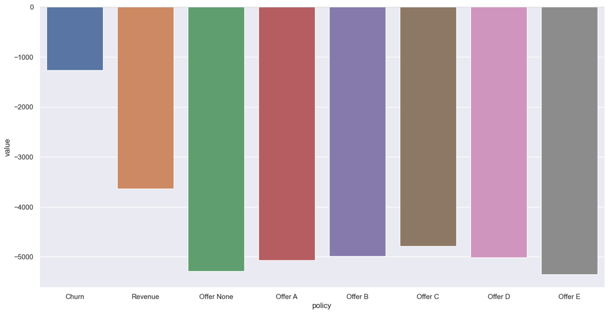

```python
policies = [policy_churn, policy_revenue, policy_churn_offer_none, policy_churn_offer_a,
            policy_churn_offer_b, policy_churn_offer_c, policy_churn_offer_d, policy_churn_offer_e]
df_results = pd.DataFrame()
df_results['policy'] = [ 'Churn', 'Revenue','Offer None', 'Offer A', 'Offer B', 'Offer C', 'Offer D', 'Offer E']
df_results['value'] = [evaluate_policy(df, policy) for policy in policies]

fig, ax = plt.subplots()
sns.barplot(df_results, x='policy', y='value')
plt.axhline(0, c='k')
```

The result is starking if we compare all the different policies.